# RNAseAlert kit test 03

Jan Sklenar

01/04/2020

# What is causing suppression of fluorescense when Cas13 is added?

## Design

- Cas13/impurities had an effect on fluorescence.
- We need to test Cas13 with and without its buffer to see what component has bearing on RFU.
- We need to test DEPC in HEPES again, the first test did not work.
- Phosphate in higher concentration and generally ionic strength have profound effect on Benzoase. We can try 20mM Phosphate buffer.

#### Chemicals used in the reaction,

added in the following order in replicates of four, in squares on 96 well plate:

1. 20mM HEPES ph 7.0 buffer
2. Benzoase(TM)nuclease, 25U/ml stock solution
3. DEPC (inhibitor), 0.1% in the reaction
4. Imidazole (inhibitor quencher), 10mM in the reaction
5. Benzoase(TM)nuclease (fresh enzyme after the background has been inhibited)
6. Cas13 2mg/ml was diluted: 5ul/153ul in Storage buffer (Josie), which gives 10x concentrated protein solution. For this test it is diluted to give 1x, 0.2x, and 0.01X diluted prtoein and bufer.
7. substrate (fluorescein-RNA conjugate), two tubes designed for one test are here use for all the test - diluted to use 5ul in 48 replicates.

#### Test conditions (volumes in microliters per well)

[figure not shown]

Copy of original table in Excel.

## Data preparation

### Read in data and parse some sample names

### Corrections

Errors happen, see the table above.

```r
## ## Condition 1 and 2 are the same thing. Create new SampleComb where 2 is replace with 1

raw$SampleComb <- raw$SampleNo
raw[raw$SampleComb==2,"SampleComb"] <- 1

unique(raw$SampleNo)
```

```
##  [1] "1"  "2"  "3"  "4"  "5"  "6"  "7"  "8"  "9"  "10" "11" "12"
```

```r
unique(raw$SampleComb)
```

```
##  [1] "1"  "3"  "4"  "5"  "6"  "7"  "8"  "9"  "10" "11" "12"
```

```r
#' Which means the control with +RNAse has 8 replicates, unlike all the other conditions that has only 4.
```

### Subset of data for plotting

```r
## show cleaned data with selected columns
#' Well, Sample, SampleNo, RepNo, MeasTimeSec, RFU
df <- raw[,c(3,6,11,12,7,8,13)]
head(df)
```

```
##   Well Sample SampleNo RepNo MeasTimeSec      RFU SampleComb
## 1  A01  1 1/4        1     1        0.00 1.158220          1
## 2  B01  1 2/4        1     2        0.55 1.195040          1
## 3  C01  2 1/4        2     1        1.10 1.178240          1
## 4  D01  2 2/4        2     2        1.65 1.080520          1
## 5  E01  3 1/4        3     1        2.20 0.246303          3
## 6  F01  3 2/4        3     2        2.75 0.248450          3
```

```r
str(df)
```

```
## 'data.frame':    1152 obs. of  7 variables:
##  $ Well       : chr  "A01" "B01" "C01" "D01" ...
##  $ Sample     : chr  "1 1/4" "1 2/4" "2 1/4" "2 2/4" ...
##  $ SampleNo   : chr  "1" "1" "2" "2" ...
##  $ RepNo      : chr  "1" "2" "1" "2" ...
##  $ MeasTimeSec: num  0 0.55 1.1 1.65 2.2 2.75 3.3 3.85 4.4 4.95 ...
##  $ RFU        : num  1.158 1.195 1.178 1.081 0.246 ...
##  $ SampleComb : chr  "1" "1" "1" "1" ...
```

## Plots

### All data

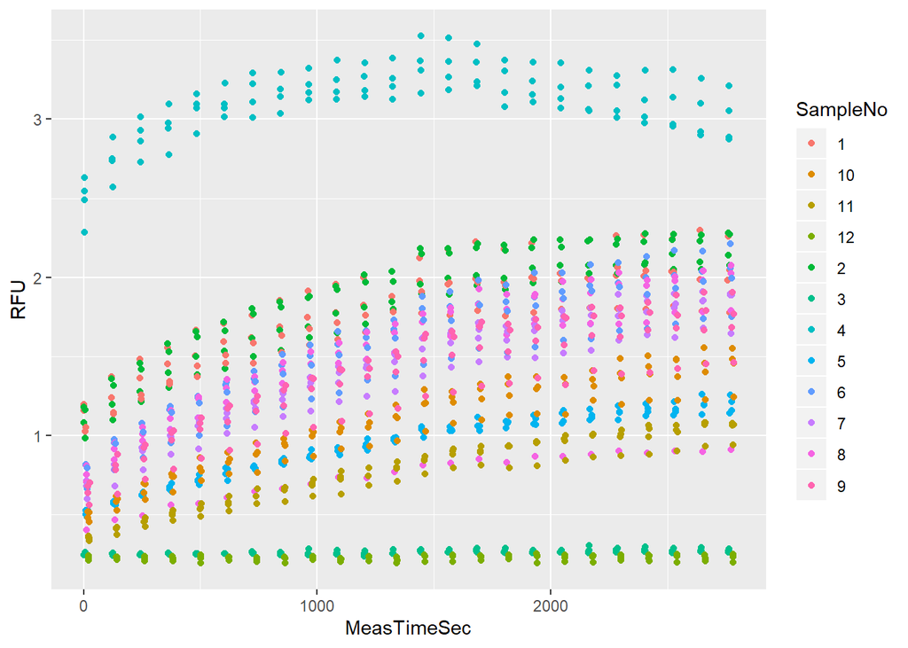

```r
#' all the data
#plot(x=raw$MeasTimeSec,y=raw$RFU)

#' colour labeled samples
ggplot(data = df) +
  aes(x = MeasTimeSec, y=RFU) +
  geom_point(aes(color=SampleNo))
```

### Adjustments (if needed)

```r
# ## some adjustments
# ## Use summary statistics (mean) to find and remove obvious  outlier in  sample 3
# #' means of all replicates of sample 3
# dfstat <- df %>% filter(SampleNo==1) %>% group_by(SampleNo,RepNo) %>% summarise(mean=mean(RFU))
# dfstat
# #' Data that should be removed
# filter(df,SampleNo == 3 & RepNo == 3)
# #' I could not invert the filter though
# #' But it is the same as leaving out all the measurement from the well E01
# dfs <- filter(df, Well != "E06")
# #' all the measurements
# length(rownames(df))
# #'after 12 datapoints were removed
# length(rownames(dfs))
```

### All data with description

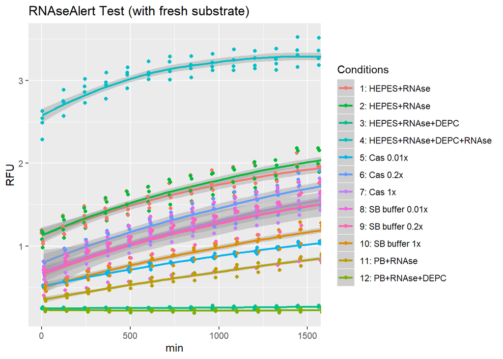

```r
## LOESS regression
p <- ggplot(data = df) +
  aes(x = MeasTimeSec, y=RFU) +
  geom_smooth(aes(color=SampleNo)) +
  geom_point(aes(colour=SampleNo))

  p + labs(title = "RNAseAlert Test (with fresh substrate)", x = "min",   y = "RFU", color = "Legend Title\n") +
  coord_cartesian(xlim = c(0,1500)) +
  scale_colour_discrete(name="Conditions",
                      breaks=c(1,2,3,4,5,6,7,8,9,10,11,12),
                      labels=c("1: HEPES+RNAse",
                               "2: HEPES+RNAse",
                               "3: HEPES+RNAse+DEPC",
                               "4: HEPES+RNAse+DEPC+RNAse",
                               "5: Cas 0.01x",
                               "6: Cas 0.2x",
                               "7: Cas 1x",
                               "8: SB buffer 0.01x",
                               "9: SB buffer 0.2x",
                               "10: SB buffer 1x",
                               "11: PB+RNAse",
                               "12: PB+RNAse+DEPC"))
```

Not very readable. Let us split it.

### Ploting subsets by conditions being tested

This chunk is not going to be very ellegant; The annotation of all plots differ and we compare the same control with other measuremetns several time. Facet_wrap would be more elegant, but it does not give me flexibility to group plots that is neede here.

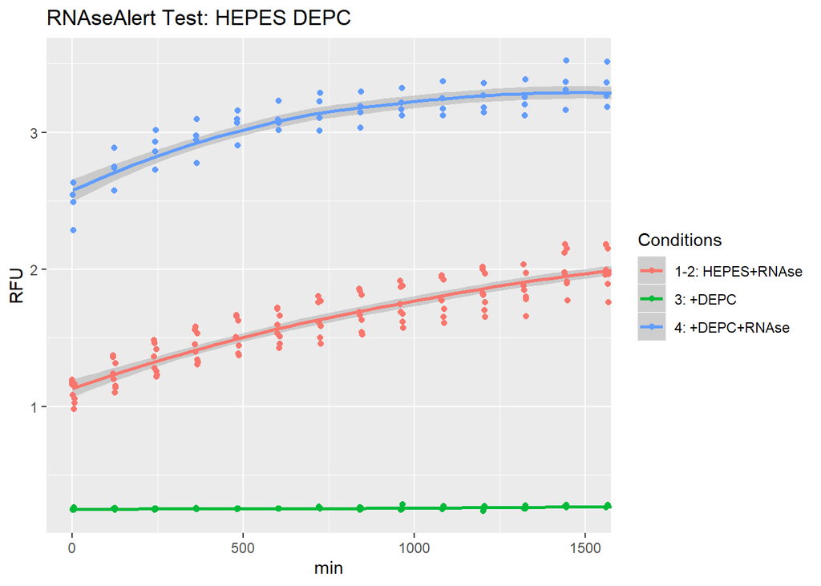

```r
## HEPES_DEPC
p <- raw[raw$SampleComb==1|raw$SampleComb==3|raw$SampleComb==4,]
## LOESS regression
p <- ggplot(data = p) +
  aes(x = MeasTimeSec, y=RFU) +
  geom_smooth(aes(color=SampleComb)) +
  geom_point(aes(colour=SampleComb))

  p + labs(title = "RNAseAlert Test: HEPES DEPC", x = "min",   y = "RFU", color = "Legend Title\n") +
  coord_cartesian(xlim = c(0,1500)) +
  scale_colour_discrete(name="Conditions",
                      breaks=c(1,3,4),
                      labels=c("1-2: HEPES+RNAse",
                               "3: +DEPC",
                               "4: +DEPC+RNAse"))
```

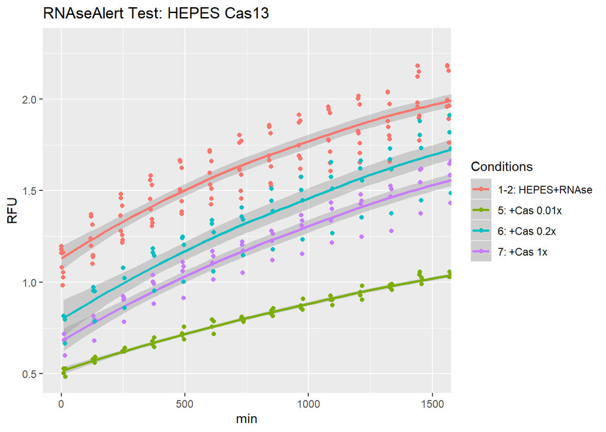

```r
## HEPES Cas13
p <- raw[raw$SampleComb==1|raw$SampleComb==5|raw$SampleComb==6|raw$SampleComb==7,]
## LOESS regression
p <- ggplot(data = p) +
  aes(x = MeasTimeSec, y=RFU) +
  geom_smooth(aes(color=SampleComb)) +
  geom_point(aes(colour=SampleComb))

  p + labs(title = "RNAseAlert Test: HEPES Cas13", x = "min",   y = "RFU", color = "Legend Title\n") +
  coord_cartesian(xlim = c(0,1500)) +
  scale_colour_discrete(name="Conditions",
                      breaks=c(1,5,6,7),
                      labels=c("1-2: HEPES+RNAse",
                               "5: +Cas 0.01x",
                               "6: +Cas 0.2x",
                               "7: +Cas 1x"))
```

[figure not shown]

```r
## HEPES Cas13 buffer
p <- raw[raw$SampleComb==1|raw$SampleComb==8|raw$SampleComb==9|raw$SampleComb==10,]
## LOESS regression
p <- ggplot(data = p) +
  aes(x = MeasTimeSec, y=RFU) +
  geom_smooth(aes(color=SampleComb)) +
  geom_point(aes(colour=SampleComb))

  p + labs(title = "RNAseAlert Test: HEPES Cas13 buffer", x = "min",   y = "RFU", color = "Legend Title\n") +
  coord_cartesian(xlim = c(0,1500)) +
  scale_colour_discrete(name="Conditions",
                      breaks=c(1,8,9,10),
                      labels=c("1-2: HEPES+RNAse",
                               "8: +Cas 0.01x",
                               "9: +Cas 0.2x",
                               "10: +Cas 1x"))
```

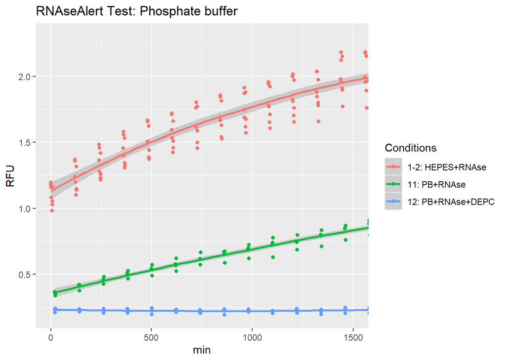

```r
## Phosphate buffer
p <- raw[raw$SampleComb==1|raw$SampleComb==11|raw$SampleComb==12,]
## LOESS regression
p <- ggplot(data = p) +
  aes(x = MeasTimeSec, y=RFU) +
  geom_smooth(aes(color=SampleComb)) +
  geom_point(aes(colour=SampleComb))

  p + labs(title = "RNAseAlert Test: Phosphate buffer", x = "min",   y = "RFU", color = "Legend Title\n") +
  coord_cartesian(xlim = c(0,1500)) +
  scale_colour_discrete(name="Conditions",
                      breaks=c(1,11,12),
                      labels=c("1-2: HEPES+RNAse",
                               "11: PB+RNAse",
                               "12: PB+RNAse+DEPC"))
```

## Conclutions

### Good:

- DEPC inhibition works.
- Phosphate buffer in lower concentration works, the acitvity is lower.

### Not very good:

- The reaction were too diluted by mistake.
- It seems Cas13 storage buffer inhibits the signal.

### What next:

- We need to test real situation, Benzoase activity is irelevant after all.
- Now we know the assay works and some limits, we need start measuring Cas13 activity.